# Changes in Forestation Levels

Ramou Jallow

February 26, 2019

## Overview

##### This report will explore a data set about forest area, as provided by the World Bank database of World Development Indicators. Visualizations will be provided that analyze the changes in forestry levels over time, as well as how different factors have impacted the forestry levels all over the world.

## Summary Visualizations

### Average Forest Area Plot

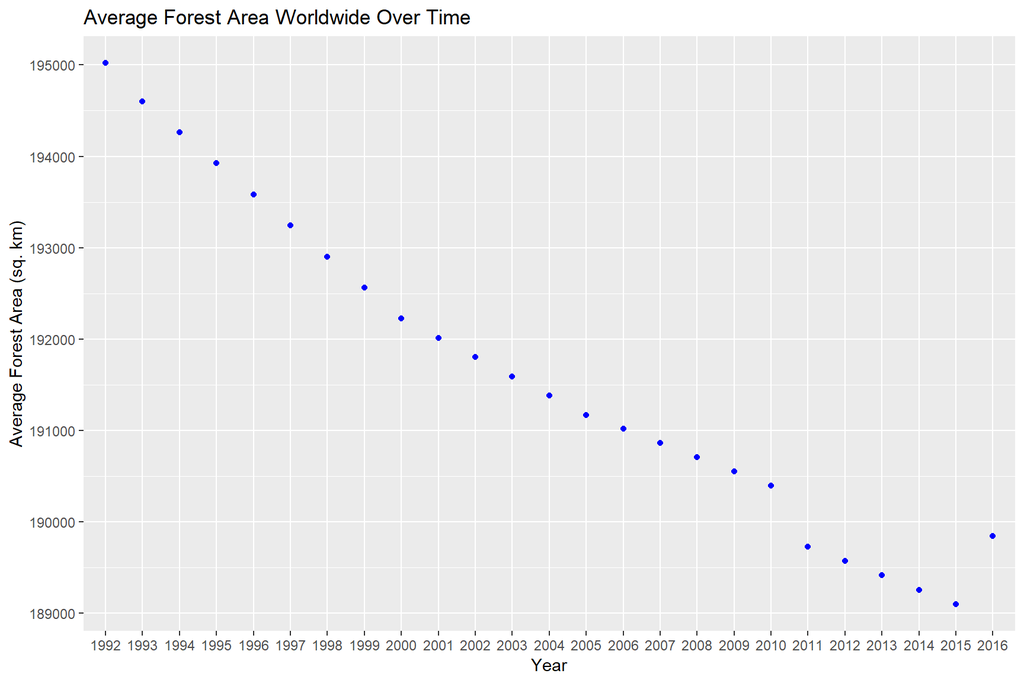

*Description: The plot above, displays how the average forest area for every country in the world, measured in square kilometers, has changed over time from the years of 1992 to 2016.*

### Forest Area versus Population Plot

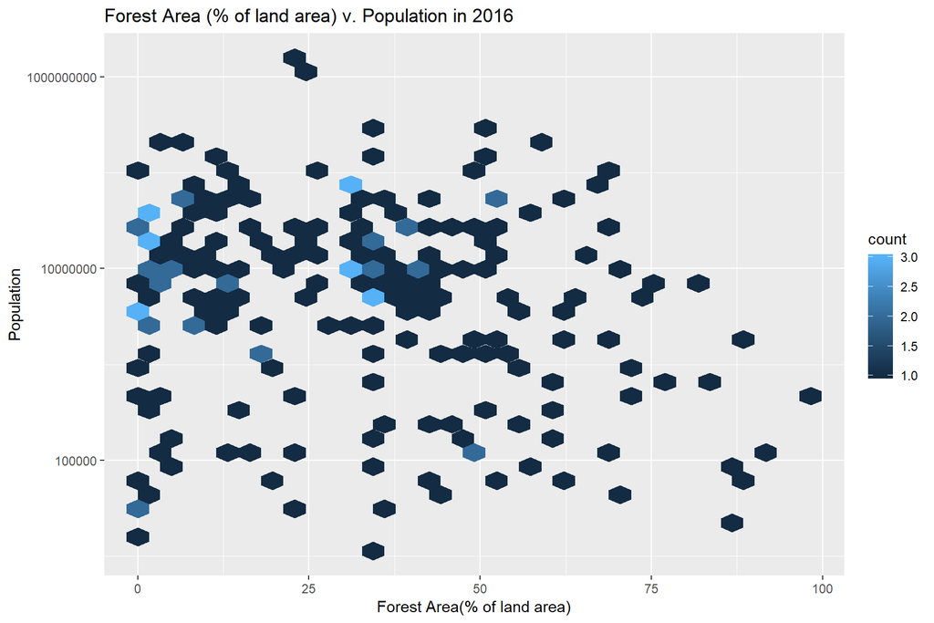

*Description: The plot above uses data from the year 2016, such as the population in each country, and the forest area measured as a percentage of the total land area, to display their relationship across multiple countries.*

## Map Visualization

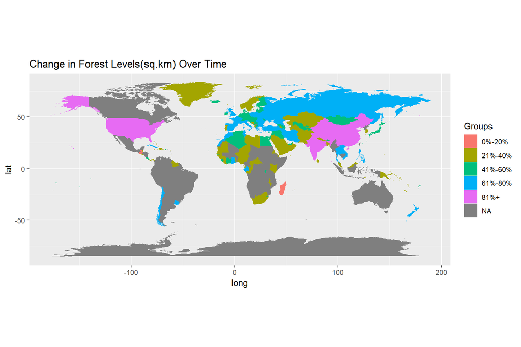

*Description: This map, shows a visualization of the change in forest levels in square kilometers from 1992 to 2016. The grey areas are regions where no data was provided, and the legend colors the countries based on the amount of forest area that was gained or lost over time.*

## Refrences

- The World Bank (https://databank.worldbank.org/data/home.aspx)
- World Development Indicators (http://datatopics.worldbank.org/world-development-indicators/)